# GLM para dados discretos

Samuel Lima & Niege Félix

# 1 Introdução

Carregando pacotes a serem utilizados e importando o banco de dados

```r
library(ggplot2)
library(ggeffects)
library(GGally) #pairsplot
library(dplyr)
library(DHARMa)
library(performance)
library(MASS) #Para rodar modelo Binomial Negativo
library(sp) #Para a visualização dos resíduos no espaço

bd <- read.csv("../Dados/bd_analises2.csv")
```

Para exercitar o GLM para dados discretos vamos utilizar os dados coletados como parte da pesquisa de mestrado do Samuel Lima (UFRN).

O bando de dados trata-se de insetos coletados em árvores plantadas de um experimento de biodiversidade e funcionamento de ecossistemas focado na restauração da Caatinga. A coleta foi realizada manualmente, por busca ativa, no final da estação chuvosa de 2023.

Saiba mais do experimento [aqui](https://brazildry.wixsite.com/treediv).

Objetivo: testar se a riqueza de espécies e o potencial de facilitação de árvores afetam a abundância de insetos no semiárido brasileiro.

Hipótese: a riqueza de espécies e o potencial de facilitação de árvores influenciam positivamente e de forma interativa a abundância de insetos

# 2 Análise exploratória

Vamos iniciar cOnhecendo nossos dados:

```r
head(bd)
```

```
##   plot       lat      long                        composition plant_richness
## 1    1 -5.539614 -36.96378                                Clp              1
## 2    2 -5.539602 -36.96353                                 Bc              1
## 3    3 -5.539489 -36.96355                          CvSmZjAcl              4
## 4    4 -5.539524 -36.96378 MtPsClCvSmLfClpHiPmApZjBcPgAclChAc             16
## 5    5 -5.539434 -36.96392                  MtPsClClpHiApChAc              8
## 6    6 -5.539434 -36.96378                               CvZj              2
##   plant_richness_log2 facilitation insect_richness insect_abundance live_plants
## 1                   0     1.499000               7               38          31
## 2                   0     0.788000               8               41          32
## 3                   2    -1.947000               4               12          30
## 4                   4     1.184313              10               31          32
## 5                   3     2.966500               8               46          31
## 6                   1    -0.121000               8               26          32
```

Visualizando a natureza em que as variáveis foram importadas e transformando as variáveis `plot` e `composition` em fator

```r
str(bd)
```

```
## 'data.frame':    146 obs. of  10 variables:
##  $ plot               : int  1 2 3 4 5 6 7 8 10 11 ...
##  $ lat                : num  -5.54 -5.54 -5.54 -5.54 -5.54 ...
##  $ long               : num  -37 -37 -37 -37 -37 ...
##  $ composition        : chr  "Clp" "Bc" "CvSmZjAcl" "MtPsClCvSmLfClpHiPmApZjBcPgAclChAc" ...
##  $ plant_richness     : int  1 1 4 16 8 2 1 2 1 1 ...
##  $ plant_richness_log2: int  0 0 2 4 3 1 0 1 0 0 ...
##  $ facilitation       : num  1.499 0.788 -1.947 1.184 2.966 ...
##  $ insect_richness    : int  7 8 4 10 8 8 2 5 2 2 ...
##  $ insect_abundance   : int  38 41 12 31 46 26 2 14 3 13 ...
##  $ live_plants        : int  31 32 30 32 31 32 10 32 15 32 ...
```

```r
bd$plot<-as.factor(bd$plot)
```

Abundância e riqueza insetos

```r
bd %>%
  summarise(Abundancia = sum(insect_abundance),
            Riqueza = sum(insect_richness))
```

```
##   Abundancia Riqueza
## 1       2561     740
```

## 2.1 Observando tendências para nossa variável resposta

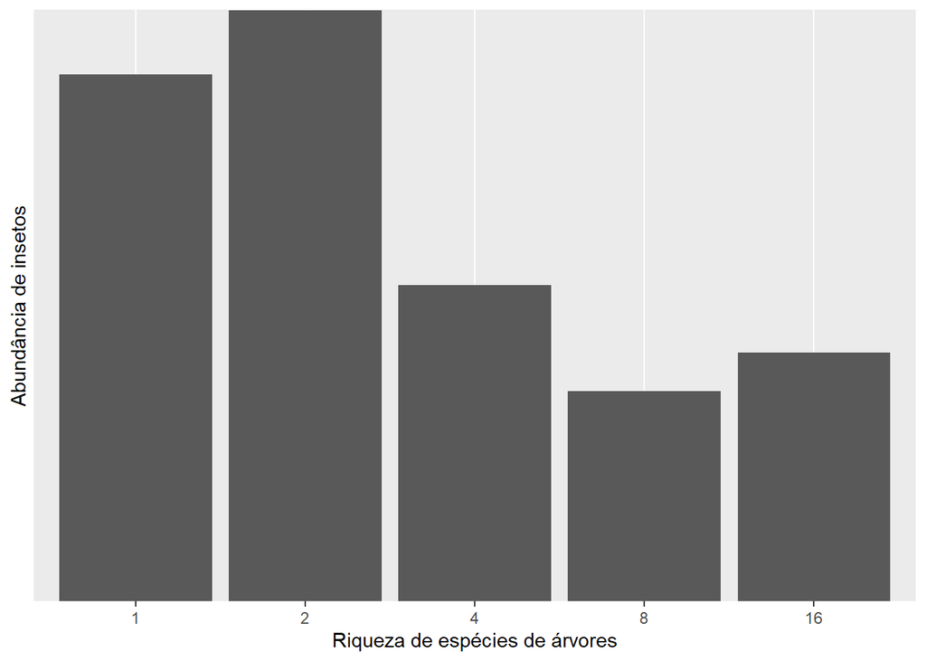

```r
##Abundância de insetos por riqueza de espécies de árvores

# Valores brutos
ggplot(bd, aes(x=factor(plant_richness),y=insect_abundance)) +
  geom_bar(stat = "identity")+
  scale_y_discrete(name = "Abundância de insetos")+
  scale_x_discrete(name = "Riqueza de espécies de árvores")
```

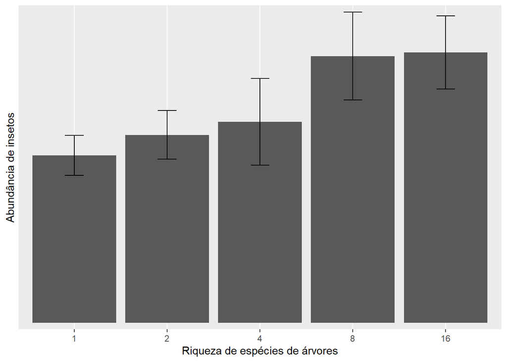

```r
# Valores médios
ggplot(bd, aes(x=factor(plant_richness),y=insect_abundance)) +
  stat_summary(geom = "bar", fun = "mean") +
  stat_summary(geom = "errorbar", width = .2, fun.data = mean_se) +
  scale_y_discrete(name = "Abundância de insetos")+
  scale_x_discrete(name = "Riqueza de espécies de árvores")
```

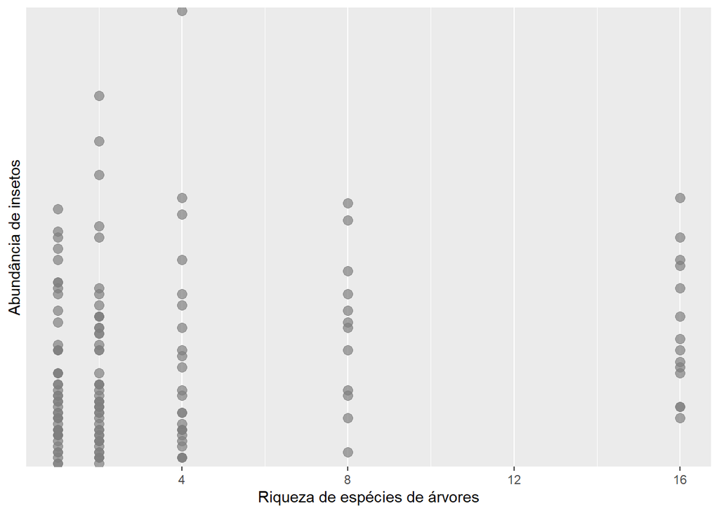

```r
# Riqueza de espécies como variável contínua
ggplot(bd,aes(x=plant_richness,y=insect_abundance))+
  geom_point(size = 3, col = 'gray50',alpha = 0.7)+
  scale_y_discrete(name = "Abundância de insetos")+
  scale_x_continuous(name = "Riqueza de espécies de árvores")
```

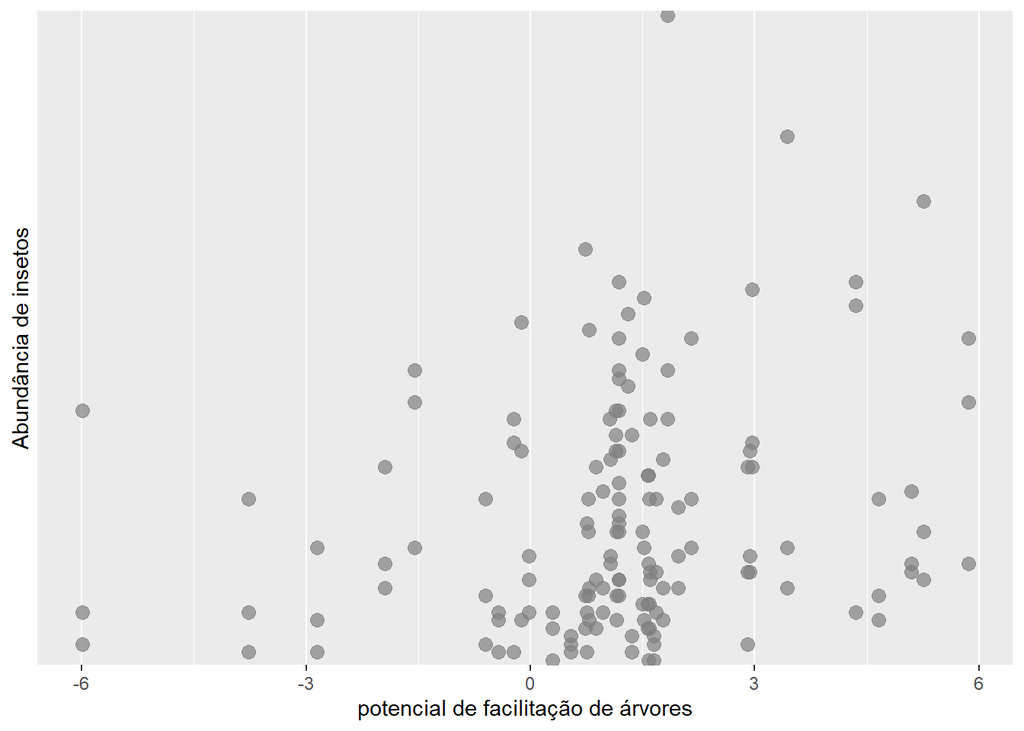

```r
## Abundância de insetos por potencial de facilitação de árvores
ggplot(bd,aes(x=facilitation,y=insect_abundance)) +
  geom_point(size = 3, col = 'gray50',alpha = 0.7) +
  scale_y_discrete(name = "Abundância de insetos") +
  scale_x_continuous(name = "potencial de facilitação de árvores")
```

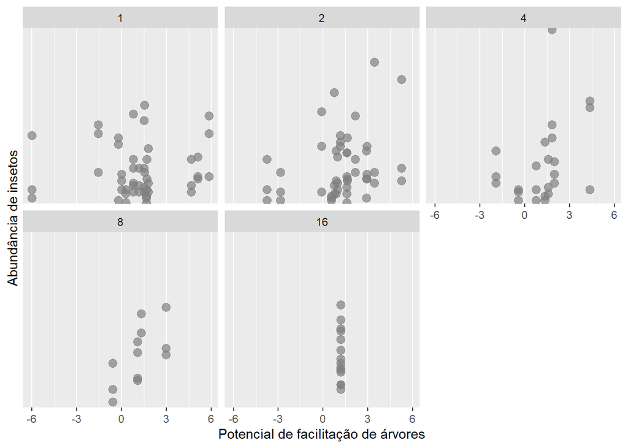

```r
## Mesma relação, mas observando separadamente pelo nível de riqueza de espécies de árvores
ggplot(bd,aes(x=facilitation,y=insect_abundance))+
  geom_point(size = 3, col = 'gray50',alpha = 0.7) +
  scale_y_discrete(name = "Abundância de insetos") +
  scale_x_continuous(name = "Potencial de facilitação de árvores") +
  facet_wrap(factor(plant_richness) ~ .)
```

Os pontos estão estruturados na vertical na última figura porque o potencial de facilitação é calculado como uma média das espécies presentes na parcela. As parcelas de 16 espécies tem o mesmo potencial de facilitação por todas as suas réplicas consistirem nas mesmas espécies (o número máximo plantado no experimento)

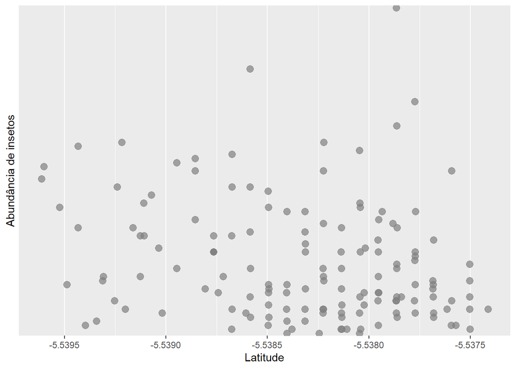

```r
##Abundância de insetos por latitude e longitude
ggplot(bd,aes(x=lat,y=insect_abundance))+
  geom_point(size = 3, col = 'gray50',alpha = 0.7)+
  scale_y_discrete(name = "Abundância de insetos")+
  scale_x_continuous(name = "Latitude")
```

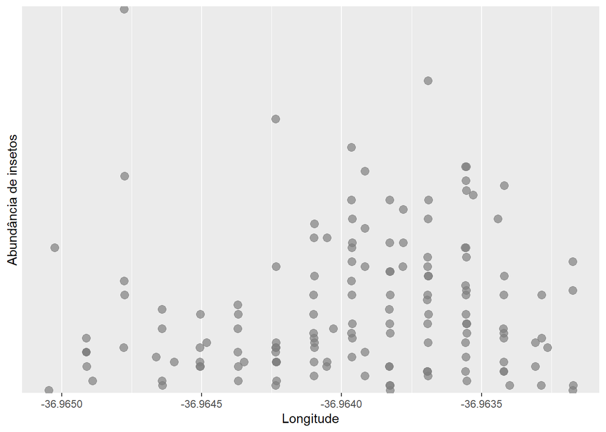

```r
ggplot(bd,aes(x=long,y=insect_abundance))+
  geom_point(size = 3, col = 'gray50',alpha = 0.7)+
  scale_y_discrete(name = "Abundância de insetos")+
  scale_x_continuous(name = "Longitude")
```

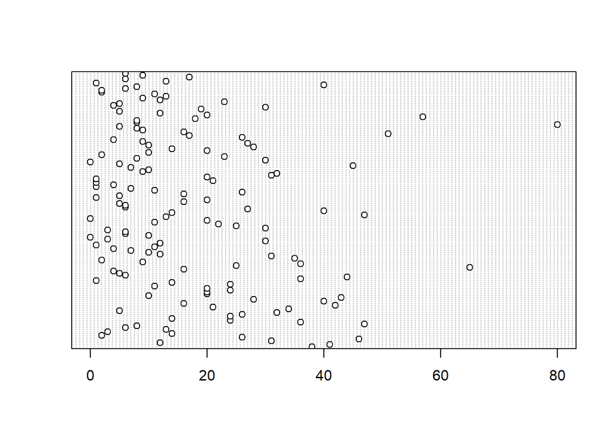

```r
# Verificando outliers
dotchart(bd$insect_abundance)
```

Sem outliers aparentes

## 2.2 Escalando as variáveis preditoras e verificando correlação

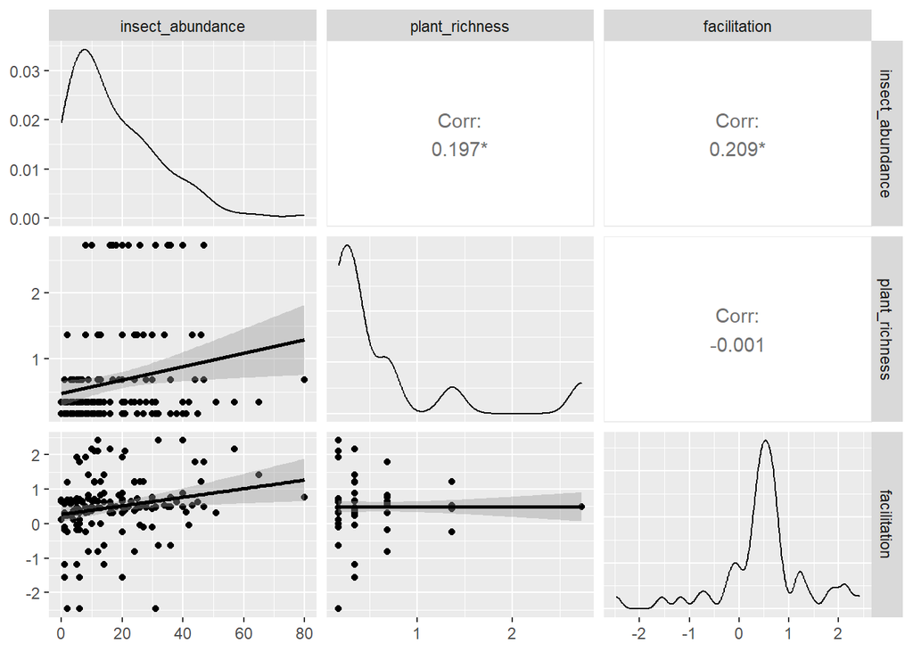

```r
cols<-c("plant_richness", "facilitation")
bd[,cols] <- scale(bd[,cols], scale=T, center=F)

ggpairs(bd,
        columns = c(9,5,7),
        lower = list(continuous = "smooth"))
```

> Sem correlação! Vamos iniciar a modelagem da abundância de insetos

# 3 Metodologia

Para testar se a riqueza de espécies e o potencial de facilitação de árvores afetam a abundância de insetos, vamos utilizar modelos de regressão com as distribuições de erro de poisson e binomial negativa, visto que a variável resposta (*insect_abundance*) é discreta (contagem de indivíduos).

Podemos resumir os modelos conforme:

$$\large y_i \sim
Poisson(\lambda_i)$$

Onde $\large \lambda_i$ é numéro médio de eventos (no nosso caso, a abundância média de insetos por parcela)

$$\large E[y_i] = \lambda_i, ~~~~~Var(y_i)
= \lambda_i$$

Aqui a variância é igual a média.

$$\large y_i \sim BN(\mu_i,
k_i)$$

$$E[y_i] = \mu_i, ~~~~~Var(y_i) = \mu_i +
\frac{\mu_i^2}{k_i}$$

Onde: - $\mu$: média da distribuição BN - $k$: parâmetro de dispersão (*forma/shape*) - dado como *theta* no output do modelo

Em ambas distrbuições, a função de ligação é a função logarítmica. Para que o dado de contagem fique sempre na escala de positivo.

## 3.1 Selecionando o modelo

```r
# Iniciando apenas com as variáveis fixas do experimento BrazilDry e com a
#distribuição de probabilidade poisson
mod_1<- glm(insect_abundance ~ plant_richness + facilitation,
            data = bd,
            family = "poisson")

# testando a interação da riqueza de espécies e a facilitação de árvores
mod_1b<- glm(insect_abundance ~ plant_richness * facilitation,
             data = bd,
             family = "poisson")

AIC(mod_1, mod_1b) #Comparando
```

```
##        df      AIC
## mod_1   3 2164.152
## mod_1b  4 2102.858
```

```r
#Testando se há sobredispersão
mod_1$deviance/mod_1$df.residual
```

```
## [1] 10.73765
```

```r
mod_1b$deviance/mod_1b$df.residual
```

```
## [1] 10.36754
```

O modelo com a interação entre as variáveis se mostrou bem melhor. Porém, ambos apresentaram uma forte sobredispersão (phi > 1).

Vamos ponderar pela diferença de esforço (plantas vivas) e comparar novamente. O esforço entra no modelo como `offset`, uma variável preditora especial que não tem parâmetro para ser estimado.

```r
mod_2<- glm(insect_abundance ~ plant_richness * facilitation +
              offset(log(live_plants)),
              data = bd,
              family = "poisson")

AIC(mod_1b, mod_2)
```

```
##        df      AIC
## mod_1b  4 2102.858
## mod_2   4 1990.257
```

> Funcionou! Seguimos com o modelo 2

O próximo passo é verificar se está tudo ok com os resíduos do modelo..

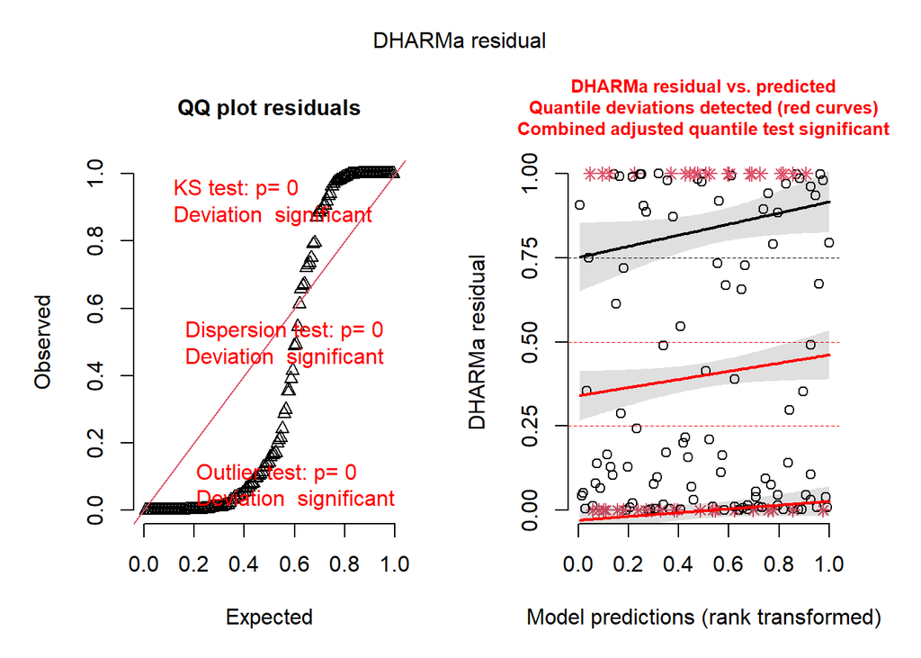

```
## Object of Class DHARMa with simulated residuals based on 1000 simulations with refit = FALSE . See ?DHARMa::simulateResiduals for help.
##
## Scaled residual values: 1 1 0.6136246 0.6726985 0.7954892 0.9836685 0.04333388 0.09470268 0.01146566 0.1636612 0.001300211 0.0101857 1 0.9985784 0.009157412 0.216065 0.9183616 0.4920793 0.998 0.001 ...
```

```r
## Inspecção residual
simulateResiduals(mod_2, n=1000,plot = T)
```

Péssimo ajuste! Os resíduos estão bem diferentes do esperado pelo modelo. Vamos testar o mesmo modelo com uma distribuição diferente

```r
#Mesmas variáveis, mas agora utilizando a função `glm.nb`, que considerada a
#distribuição de erro binomial negativa
mod_3<- glm.nb(insect_abundance ~ plant_richness * facilitation +
                 offset(log(live_plants)),
                 data = bd)

AIC(mod_2, mod_3)
```

```
##       df      AIC
## mod_2  4 1990.257
## mod_3  5 1107.232
```

> Funcionou! Seguimos com a distribuição binomial negativa

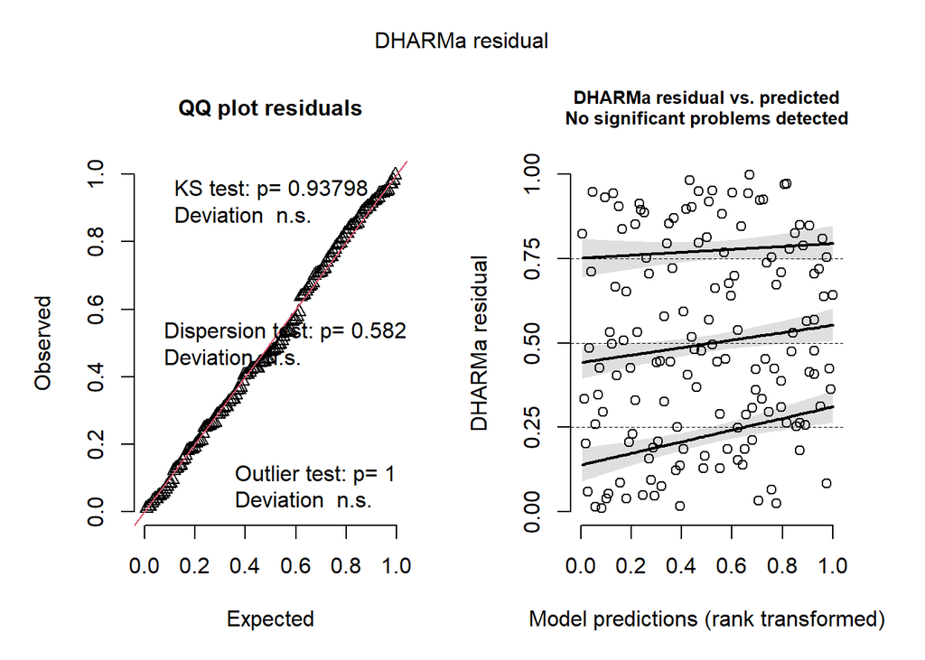

```
## Object of Class DHARMa with simulated residuals based on 1000 simulations with refit = FALSE . See ?DHARMa::simulateResiduals for help.
##
## Scaled residual values: 0.9196612 0.9454399 0.6667189 0.6379102 0.6426233 0.7966681 0.3333176 0.4532091 0.2593712 0.4521449 0.2111828 0.2887157 0.848218 0.8246159 0.3621868 0.5184199 0.7676143 0.5680065 0.8817828 0.1382896 ...
```

```r
## Inspecção residual
simulateResiduals(mod_3, n=1000, plot = T)
```

```r
check_overdispersion(mod_3)
```

```
## # Overdispersion test
##
##  dispersion ratio = 0.871
##           p-value = 0.632
```

Agora sim. Resíduos bem ajustados e sem sobredispersão.

Como previamente observamos uma tendência de agregação dos dados no espaço, vamos testar o efeito aditivo e interativo do componente espacial

```r
mod_4 <- glm.nb(insect_abundance ~ plant_richness * facilitation +
                  lat + long +
                  offset(log(live_plants)),
                  data = bd)

mod_5 <- glm.nb(insect_abundance ~ plant_richness * facilitation +
                  lat * long +
                  offset(log(live_plants)),
                data = bd)

AIC(mod_3,mod_4,mod_5)
```

```
##       df      AIC
## mod_3  5 1107.232
## mod_4  7 1109.359
## mod_5  8 1111.295
```

Não há diferença expressiva entre os modelos 3 e 4.

Vamos verificar pelo teste da razão de verossimilhança:

```r
anova(mod_3,mod_4)
```

```
## Likelihood ratio tests of Negative Binomial Models
##
## Response: insect_abundance
##                                                                   Model
## 1              plant_richness * facilitation + offset(log(live_plants))
## 2 plant_richness * facilitation + lat + long + offset(log(live_plants))
##      theta Resid. df    2 x log-lik.   Test    df LR stat.   Pr(Chi)
## 1 1.797320       142       -1097.232
## 2 1.824764       140       -1095.359 1 vs 2     2 1.873087 0.3919803
```

Ainda sem diferenças expressivas. Porém, vamos fazer uma análise gráfica dos resíduos espaciais com e sem as variáveis de latitude e longitude:

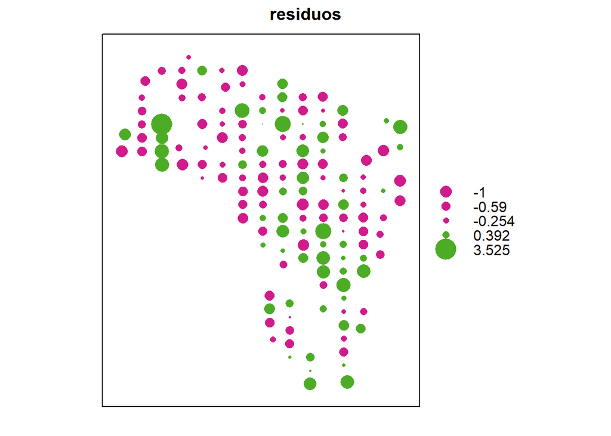

```r
##Modelo sem a lat e long
dados_sp1 <- data.frame(bd[, c("long", "lat")], mod_3$residuals)
colnames(dados_sp1)[3] <- "residuos"

coordinates(dados_sp1) <- c("long", "lat")
bubble(dados_sp1, "residuos")
```

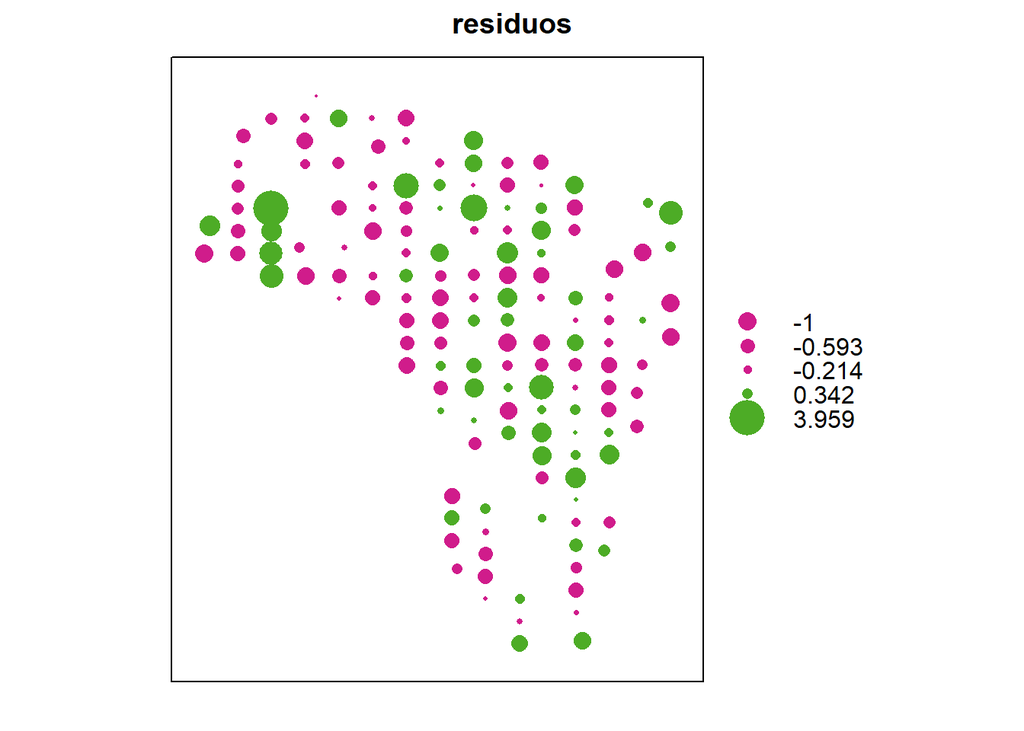

```r
##Modelo com lat e long
dados_sp2 <- data.frame(bd[, c("long", "lat")], mod_4$residuals)
colnames(dados_sp2)[3] <- "residuos"

coordinates(dados_sp2) <- c("long", "lat")
bubble(dados_sp2, "residuos")
```

# 4 Resultados

```r
summary(mod_4)
```

```
##
## Call:
## glm.nb(formula = insect_abundance ~ plant_richness * facilitation +
##     lat + long + offset(log(live_plants)), data = bd, init.theta = 1.824764351,
##     link = log)
##
## Coefficients:
##                              Estimate Std. Error z value Pr(>|z|)
## (Intercept)                 -207.0421  6287.3686  -0.033   0.9737
## plant_richness                -0.1514     0.1746  -0.867   0.3858
## facilitation                  -0.0994     0.1267  -0.784   0.4328
## lat                         -154.2141   135.4309  -1.139   0.2548
## long                          17.5206   160.0224   0.109   0.9128
## plant_richness:facilitation    0.7205     0.3114   2.314   0.0207 *
## ---
## Signif. codes:  0 '***' 0.001 '**' 0.01 '*' 0.05 '.' 0.1 ' ' 1
##
## (Dispersion parameter for Negative Binomial(1.8248) family taken to be 1)
##
##     Null deviance: 179.22  on 145  degrees of freedom
## Residual deviance: 161.90  on 140  degrees of freedom
## AIC: 1109.4
##
## Number of Fisher Scoring iterations: 1
##
##
##               Theta:  1.825
##           Std. Err.:  0.237
##
##  2 x log-likelihood:  -1095.359
```

Avaliando nosso modelo final, temos que a interação da riqueza de espécies e o potencial de facilitação de árvores afetou positivamente e de forma interativa a abundância de insetos. Em outras palavras, a associação positiva entre o potencial de facilitação de árvores e a abundância de insetos depende da riqueza de espécies de árvores (e vice-versa).

Importante notar que o intercepto não foi significativamente diferente de zero, o que pode ser um problema devido a incerteza. Mas vamos seguir dessa forma no momento..

A equação do nosso modelo final é:

$$log(\mu_i) = \beta_0 + \beta_1RiquezaSp
+ \beta_2Facilitacao + \beta_3RiquezaSpFacilitacao + \beta_4Lat +
\beta_5Long + log(offset(liveplants))$$

**Para melhor interpretação, vamos exponencializar nossos coeficientes por estarmos usando a distribuição de erro binomial negativa, que tem a função de ligação logarítimica**

```r
exp(mod_4$coefficients)
```

```
##                 (Intercept)              plant_richness
##                1.209912e-90                8.594911e-01
##                facilitation                         lat
##                9.053834e-01                1.060883e-67
##                        long plant_richness:facilitation
##                4.065457e+07                2.055372e+00
```